# Винятки в python

Винятки потрібні для знаходження неочікуваних ситуацій (неправильного вводу даних, відсутності файлів і т.д)

```python
first_num = 100
second_num = 0
print(first_num / second_num)
```

```
---------------------------------------------------------------------------
ZeroDivisionError                         Traceback (most recent call last)
<ipython-input-2-8c3baeb064e3> in <module>
      1 first_num = 100
      2 second_num = 0
----> 3 print(first_num / second_num)

ZeroDivisionError: division by zero
```

В даному випадку маємо exception ділення на нуль ZeroDivisionError: division by zero

```python
some_num = 1
some_text = "Hello students"
print(some_num + some_text)
```

```
---------------------------------------------------------------------------
TypeError                                 Traceback (most recent call last)
<ipython-input-3-896f54dcd07d> in <module>
      1 some_num = 1
      2 some_text = "Hello students"
----> 3 print(some_num + some_text)

TypeError: unsupported operand type(s) for +: 'int' and 'str'
```

А зараз ми спробували додати число до стрічки, що є очевидною помилкою TypeError: unsupported operand type(s) for +: 'int' and 'str'

```python
convert_to_num = int("Hello students")
```

```
---------------------------------------------------------------------------
ValueError                                Traceback (most recent call last)
<ipython-input-4-55dee659621e> in <module>
----> 1 convert_to_num = int("Hello students")

ValueError: invalid literal for int() with base 10: 'Hello students'
```

При конвертуванні тексту в int отримаємо наступну помилку ValueError: invalid literal for int() with base 10: 'Hello students'

```python
float_num = 5.0

for i in range(1, 1000):
        float_num = float_num**i
```

```
---------------------------------------------------------------------------
OverflowError                             Traceback (most recent call last)
<ipython-input-7-3391c581f1fe> in <module>
      2
      3 for i in range(1, 1000):
----> 4         float_num = float_num**i

OverflowError: (34, 'Result too large')
```

OverflowError: ('Result too large') виникає в ситуації, коли число, отримане в результаті арифметичних операцій є дуже великим, та не є в рамках даного типу

```python
print(variable_that_not_exist)
```

```
---------------------------------------------------------------------------
NameError                                 Traceback (most recent call last)
<ipython-input-8-2d9ea698ebdb> in <module>
----> 1 print(variable_that_not_exist)

NameError: name 'variable_that_not_exist' is not defined
```

Отримуємо NameError у випадку, якщо хочемо працювати зі змінною, якої не існує

```python
x = open("random_file.txt")
```

```
---------------------------------------------------------------------------
FileNotFoundError                         Traceback (most recent call last)
<ipython-input-9-2c65f11863d0> in <module>
----> 1 x = open("random_file.txt")

FileNotFoundError: [Errno 2] No such file or directory: 'random_file.txt'
```

FileNotFoundError: [Errno 2] No such file or directory: 'random_file.txt' Виникає у випадку коли ми хочемо працювати з файлом, якого немає

```python
list_of_products = ["Масло", "Шоколад", "Хліб"]

print(list_of_products[5])
```

```
---------------------------------------------------------------------------
IndexError                                Traceback (most recent call last)
<ipython-input-10-eccd94e8884e> in <module>
      1 list_of_products = ["Масло", "Шоколад", "Хліб"]
      2
----> 3 print(list_of_products[5])

IndexError: list index out of range
```

Якщо ми хочемо взяти елемент по індексу, якого не існує, виникає IndexError: list index out of range

```python
print("Ось такий сьогодні урок"))
```

```
  File "<ipython-input-11-f1f98e206014>", line 1
    print("Ось такий сьогодні урок"))
                                    ^
SyntaxError: invalid syntax
```

При помилці в синтаксисі виникає SyntaxError: invalid syntax

### Як обробляти ці помилки?

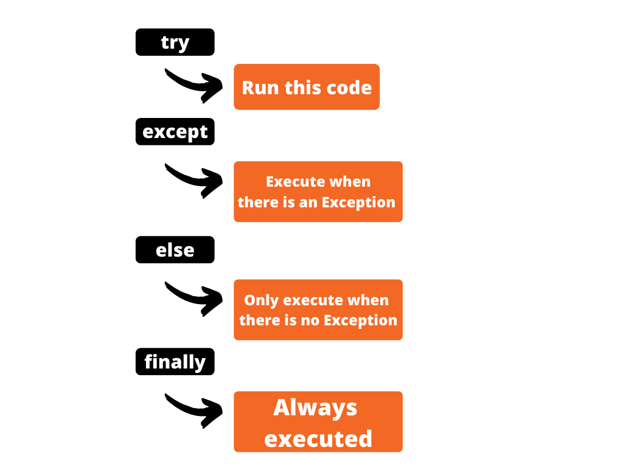

```python
try:
    number_division = 1/0
except:
    print("You divide number by zero")
```

```
You divide number by zero
```

Якщо хочемо вивести тип винятку

```python
try:
    number_division = 1/0
except Exception as e:
    print(e.__class__)
    print(f"Exception occured - {e}")
```

```
<class 'ZeroDivisionError'>
Exception occured - division by zero
```

```python
try:
    new_file = open('imaginary_file.csv', 'r')
except Exception as e:
    print(e.__class__)
    print(f"Exception occured - {e}")
```

```
<class 'FileNotFoundError'>
Exception occured - [Errno 2] No such file or directory: 'imaginary_file.csv'
```

### Блок finally спрацьовує завжди

```python
try:
    number_division = 1/0
except:
    print("You divide number by zero")
finally:
    number_division = 1
    print("Done: ", number_division)
```

```
You divide number by zero
Done:  1
```

Блок finally створений для завершення виняткової ситуації (наприклад закриття відкритих файлів, коли виникає помилка при роботі з ними)

Також за допомогою **raise** ми можемо самостійно викликати винятки

```python
raise MemoryError("BOOOOOM")
```

```
---------------------------------------------------------------------------
MemoryError                               Traceback (most recent call last)
<ipython-input-20-3ef2ade0f4db> in <module>
----> 1 raise MemoryError("BOOOOOM")

MemoryError: BOOOOOM
```

# Завдання

## 1. Створити декілька виняткових ситуацій та написати для них обробку. Випадкові ситуації, які потрібно створити:

- ZeroDivisionError
- NameError
- TypeError
- OverflowError
- ValueError

## 2. Змінити наступний код так, щоб в ньому не виникало ValueError

```python
import sys

randomList = ['a', 0, 2]

for entry in randomList:
    try:
        print("The entry is", entry)
        r = 1/int(entry)
        break
    except:
        print("Oops!", sys.exc_info()[0], "occurred.")
        print("Next entry.")
        print()
print("The reciprocal of", entry, "is", r)
```

```
The entry is a
Oops! <class 'ValueError'> occurred.
Next entry.

The entry is 0
Oops! <class 'ZeroDivisionError'> occurred.
Next entry.

The entry is 2
The reciprocal of 2 is 0.5
```

## 3. Розібрати код консольної гри. Збільшити кількість чисел з 4 до 10

```python
x = [1, 2, 3, 4]

while True:
    user_input = input("Guess a position ==> ")
    try:
        print(x[int(user_input)])
        break
    except IndexError as e:
        print(f"Guess a number between {-1*len(x)} and {len(x)-1}")
    except ValueError as e:
        print("You are only allowed integers")
```

```
Guess a position ==> 3.5
You are only allowed integers
Guess a position ==> 234
Guess a number between -4 and 3
Guess a position ==> 2
3
```

## 4. Самостійно прочитати https://www.programiz.com/python-programming/user-defined-exception про створення власних винятків. Створити будь-який 1 приклад такого класу